# codehover — a complete showcase

codehover

# What is codehover?

`codehover` turns a plot built up step by step into an **interactive code table**. You hover a row of code and the figure beside it changes to show the plot *as it looks up to that line*. It is a great way to teach how a `ggplot2` chart is assembled, one `+` at a time.

There are two ways in:

- **`ch_hover({ ... })`** — the automatic API. Give it ggplot code; it splits at every top-level `+`, renders one image per step and returns a finished, self-contained hover table (CSS and JavaScript travel with it).
- **`ch_int()` / `ch_row()` / `ch_out()`** — the manual API, for full control over the rows and the images (any images at all, not only `+` chains).

This page demonstrates **every** feature using only built-in datasets (`palmerpenguins`) and Brazilian maps from `geobr`. Hover the code rows below!

# 1. The hero: `ch_hover()` incremental

The default mode is **incremental**: hovering a row highlights it and every prior row, and the figure shows the cumulative result up to that step. Let’s build a good-looking penguins scatter plot from scratch.

| ggplot(penguins, aes(x = bill_length_mm, y = bill_depth_mm, color = species)) + |
| --- |
| geom_point(size = 2.5, alpha = 0.8) + |
| scale_color_viridis_d(option = "turbo", end = 0.85) + |
| labs(title = "Bill dimensions of Palmer penguins", subtitle = "Hover each line of code to see that step", x = "Bill length (mm)", y = "Bill depth (mm)", color = NULL) + |
| theme_minimal(base_size = 12) + |
| theme(legend.position = "top") |

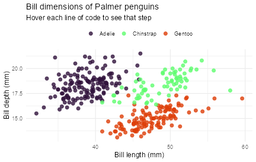

```r
ch_hover({
  ggplot(penguins, aes(x = bill_length_mm, y = bill_depth_mm, color = species)) +
    geom_point(size = 2.5, alpha = .8) +
    scale_color_viridis_d(option = "turbo", end = .85) +
    labs(
      title = "Bill dimensions of Palmer penguins",
      subtitle = "Hover each line of code to see that step",
      x = "Bill length (mm)", y = "Bill depth (mm)", color = NULL
    ) +
    theme_minimal(base_size = 12) +
    theme(legend.position = "top")
}, width = 6, height = 3.8, dpi = 72)
```

Start at the top row — just the `ggplot()` call draws an empty panel — and walk down: the points appear, get a colour palette, gain titles, then a polished theme.

# 2. Comparing viridis palettes

A fun use of the **cumulative** behaviour: stack several colour scales. Each new `scale_color_viridis_c()` *replaces* the previous one (ggplot keeps only the last scale of each type), so hovering down the rows walks you through the viridis palettes on the very same plot.

First build a complete base plot and store it in `g`:

```r
g <- ggplot(penguins, aes(x = flipper_length_mm, y = body_mass_g,
                          color = body_mass_g)) +
  geom_point(size = 2.5) +
  labs(title = "Penguin size, coloured by body mass",
       x = "Flipper length (mm)", y = "Body mass (g)", color = "Mass (g)") +
  theme_minimal(base_size = 12)
```

Now hover through the palettes:

```r
ch_hover({
  g +
    scale_color_viridis_c() +
    scale_color_viridis_c(option = "turbo") +
    scale_color_viridis_c(option = "magma") +
    scale_color_viridis_c(option = "plasma") +
    scale_color_viridis_c(option = "cividis")
}, width = 6, height = 3.8, dpi = 72)
```

| g + |
| --- |
| scale_color_viridis_c() + |
| scale_color_viridis_c(option = "turbo") + |
| scale_color_viridis_c(option = "magma") + |
| scale_color_viridis_c(option = "plasma") + |
| scale_color_viridis_c(option = "cividis") |

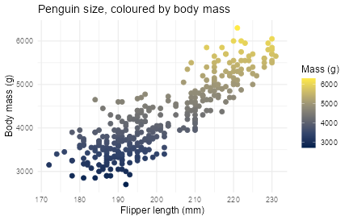

> **Note.** Because the scales are *added*, the code shown is cumulative (`+ viridis + turbo + magma + ...`). Visually only the **last** scale on each row wins, which is exactly what makes the palette-by-palette reveal work. When you want each row to be a genuinely independent plot instead, use the manual API (see Section 9).

# 3. Fixed scales and layout

## `fixed_scales`

By default every step shows the *true* output of its partial code, so axes can jump as layers change the data range. With `fixed_scales = TRUE` the axes, legends and panel layout are pinned from the **final** plot, giving a stable reveal (mechanism borrowed from the ggreveal package).

Default (axes may move between steps):

| ggplot(penguins, aes(flipper_length_mm, body_mass_g)) + |
| --- |
| geom_point(alpha = 0.5) + |
| geom_smooth(method = "lm", color = "firebrick") + |
| scale_x_continuous(limits = c(170, 235)) |

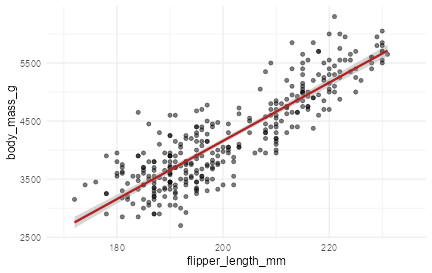

```r
ch_hover({
  ggplot(penguins, aes(flipper_length_mm, body_mass_g)) +
    geom_point(alpha = .5) +
    geom_smooth(method = "lm", color = "firebrick") +
    scale_x_continuous(limits = c(170, 235))
}, width = 6, height = 3.8, dpi = 72)
```

Same code with `fixed_scales = TRUE` (axes pinned from the start):

| ggplot(penguins, aes(flipper_length_mm, body_mass_g)) + |
| --- |
| geom_point(alpha = 0.5) + |
| geom_smooth(method = "lm", color = "firebrick") + |
| scale_x_continuous(limits = c(170, 235)) |

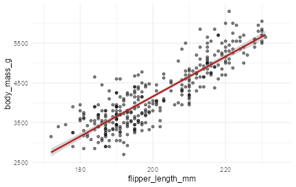

```r
ch_hover({
  ggplot(penguins, aes(flipper_length_mm, body_mass_g)) +
    geom_point(alpha = .5) +
    geom_smooth(method = "lm", color = "firebrick") +
    scale_x_continuous(limits = c(170, 235))
}, fixed_scales = TRUE, width = 6, height = 3.8, dpi = 72)
```

## `layout`

`layout` controls where the figure sits relative to the code table:

- `"auto"` (default) — side by side when there is room, image wraps below for wide code tables.
- `"row"` — always side by side; the image shrinks to fit.
- `"column"` — always below the code.

Forced **row**:

| ggplot(penguins, aes(species, body_mass_g, fill = species)) + |
| --- |
| geom_boxplot() + |
| scale_fill_viridis_d(option = "mako", end = 0.85) + |
| theme(legend.position = "none") |

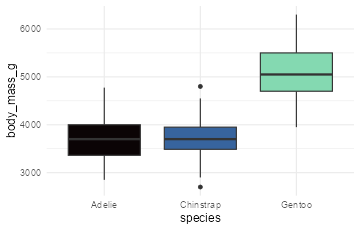

```r
ch_hover({
  ggplot(penguins, aes(species, body_mass_g, fill = species)) +
    geom_boxplot() +
    scale_fill_viridis_d(option = "mako", end = .85) +
    theme(legend.position = "none")
}, layout = "row", width = 5, height = 3.2, dpi = 72)
```

Forced **column**:

| ggplot(penguins, aes(species, body_mass_g, fill = species)) + |
| --- |
| geom_boxplot() + |
| scale_fill_viridis_d(option = "mako", end = 0.85) + |
| theme(legend.position = "none") |

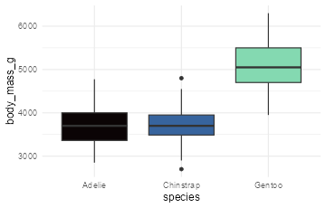

```r
ch_hover({
  ggplot(penguins, aes(species, body_mass_g, fill = species)) +
    geom_boxplot() +
    scale_fill_viridis_d(option = "mako", end = .85) +
    theme(legend.position = "none")
}, layout = "column", width = 5, height = 3.2, dpi = 72)
```

# 4. `type = "one_row"`

The other hover effect highlights **only** the hovered row instead of the row and all the rows above it. The figure still shows the cumulative result; only the highlight differs. Compare hovering here with Section 1.

| ggplot(penguins, aes(bill_length_mm, flipper_length_mm, color = island)) + |
| --- |
| geom_point(size = 2.5) + |
| scale_color_viridis_d(option = "plasma", end = 0.8) + |
| labs(x = "Bill length (mm)", y = "Flipper length (mm)", color = NULL) |

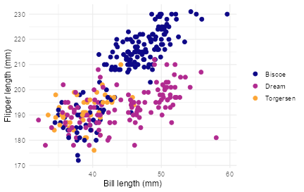

```r
ch_hover({
  ggplot(penguins, aes(bill_length_mm, flipper_length_mm, color = island)) +
    geom_point(size = 2.5) +
    scale_color_viridis_d(option = "plasma", end = .8) +
    labs(x = "Bill length (mm)", y = "Flipper length (mm)", color = NULL)
}, type = "one_row", width = 6, height = 3.8, dpi = 72)
```

# 5. Maps with `geobr`

`ch_hover()` works with anything that prints as a plot, including `sf` maps. Here we build a choropleth of the five Brazilian regions, step by step.

```r
states <- read_state(year = 2020, showProgress = FALSE)
```

| ggplot(states) + |
| --- |
| geom_sf(aes(fill = name_region), color = "white", linewidth = 0.1) + |
| scale_fill_viridis_d(option = "turbo") + |
| labs(title = "Brazil by region", fill = "Region") + |
| theme_void(base_size = 12) + |
| theme(legend.position = "bottom") |

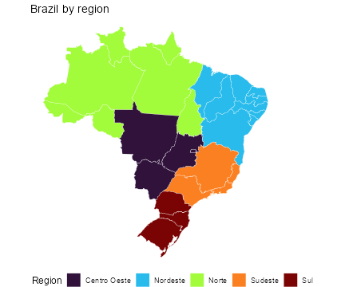

```r
ch_hover({
  ggplot(states) +
    geom_sf(aes(fill = name_region), color = "white", linewidth = .1) +
    scale_fill_viridis_d(option = "turbo") +
    labs(title = "Brazil by region", fill = "Region") +
    theme_void(base_size = 12) +
    theme(legend.position = "bottom")
}, width = 6, height = 5, dpi = 72)
```

> `geobr` caches its downloads, so the first render needs a network connection but later renders are offline.

# 6. Custom styling with `css_class`

Pass `css_class = "yourclass"` and define that class in a `<style>` block to restyle the table — the hover highlight colour, the font, borders, anything. All codehover rules are scoped under `.codehover`, so target `.yourclass tr.hover`, `.yourclass table`, and so on.

```css
.fancy table {
  font-family: "Fira Code", "Cascadia Code", monospace;
  font-size: 0.85em;
}
.fancy td {
  border-bottom: 1px solid #eee;
}
.fancy tr.hover {
  background-color: #2c3e50;   /* dark slate instead of the default yellow */
  color: #ffffff;
}
```

| ggplot(penguins, aes(body_mass_g, fill = species)) + |
| --- |
| geom_density(alpha = 0.6, color = NA) + |
| scale_fill_viridis_d(option = "rocket", end = 0.85) + |
| labs(x = "Body mass (g)", y = "Density", fill = NULL) |

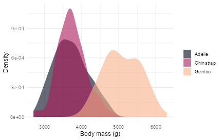

```r
ch_hover({
  ggplot(penguins, aes(body_mass_g, fill = species)) +
    geom_density(alpha = .6, color = NA) +
    scale_fill_viridis_d(option = "rocket", end = .85) +
    labs(x = "Body mass (g)", y = "Density", fill = NULL)
}, css_class = "fancy", width = 6, height = 3.8, dpi = 72)
```

For one-off tweaks you can also push inline attributes straight onto the tags via `table_tag_add` / `div_tag_add` in the manual API, e.g. `ch_int(table_tag_add = "style='background:#fafafa'")`.

# 7. Keep the source clean with `ch_hover_chunk()`

In a report you may not want the plot code written twice. Put it in a normal chunk with `eval=FALSE` and reference it **by label** with `ch_hover_chunk()`, which reads the chunk’s code and feeds it to `ch_hover()`.

```r
ggplot(penguins, aes(x = species, fill = sex)) +
  geom_bar(position = "dodge") +
  scale_fill_viridis_d(option = "cividis", end = .7, na.value = "grey80") +
  labs(x = NULL, y = "Count", fill = NULL) +
  coord_flip()
```

Then a single inline call renders the hover table:

| ggplot(penguins, aes(x = species, fill = sex)) + |
| --- |
| geom_bar(position = "dodge") + |
| scale_fill_viridis_d(option = "cividis", end = .7, na.value = "grey80") + |
| labs(x = NULL, y = "Count", fill = NULL) + |
| coord_flip() |

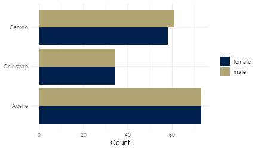

# 8. Keep the HTML small with `path =`

By default each step image is embedded in the HTML as base64, so the page is fully self-contained but can get large. Pass a folder to `path =` and codehover writes numbered PNGs to disk and references them by relative path instead — smaller HTML, but the folder must ship alongside the page.

| ggplot(penguins, aes(bill_length_mm, bill_depth_mm)) + |
| --- |
| geom_hex(bins = 18) + |
| scale_fill_viridis_c(option = "inferno") + |
| labs(x = "Bill length (mm)", y = "Bill depth (mm)", fill = "Count") |

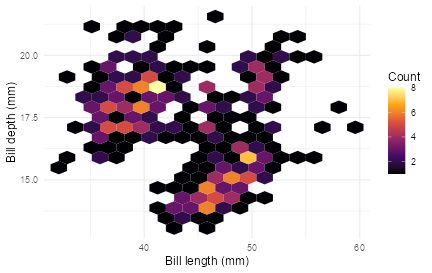

```r
ch_hover({
  ggplot(penguins, aes(bill_length_mm, bill_depth_mm)) +
    geom_hex(bins = 18) +
    scale_fill_viridis_c(option = "inferno") +
    labs(x = "Bill length (mm)", y = "Bill depth (mm)", fill = "Count")
}, path = "showcase_assets/", width = 6, height = 3.8, dpi = 72)
```

After rendering, look in `showcase_assets/` — you’ll find `codehover-1.png`, `codehover-2.png`, … one per step.

# 9. The manual API

When your steps are **not** a single ggplot `+` chain — independent plots, arbitrary images, data-wrangling stages — build the table by hand with `ch_int()` → `ch_row()` → `ch_out()`. This is also the *correct* way to compare palettes when you want each row to be a genuinely separate plot (contrast with Section 2).

Render each palette to its own PNG first:

```r
base <- ggplot(penguins, aes(flipper_length_mm, body_mass_g, color = body_mass_g)) +
  geom_point(size = 2.5) +
  labs(x = "Flipper length (mm)", y = "Body mass (g)", color = "Mass (g)") +
  theme_minimal(base_size = 12)

palettes <- c("viridis", "turbo", "magma", "plasma", "cividis")

files <- vapply(palettes, function(opt) {
  f <- tempfile(fileext = ".png")
  ggsave(f, base + scale_color_viridis_c(option = opt),
         width = 6, height = 3.8, dpi = 72)
  f
}, character(1))
```

Now assemble the table — each row is an **independent** image, and the code shown is whatever text you choose:

```r
tbl <- ch_int(type = "one_row")
for (i in seq_along(palettes)) {
  tbl <- ch_row(tbl,
                text = paste0("scale_color_viridis_c(option = \"", palettes[i], "\")"),
                img  = files[i])
}
ch_out(tbl, img = files[1])
```

| scale_color_viridis_c(option = "viridis") |
| --- |
| scale_color_viridis_c(option = "turbo") |
| scale_color_viridis_c(option = "magma") |
| scale_color_viridis_c(option = "plasma") |
| scale_color_viridis_c(option = "cividis") |

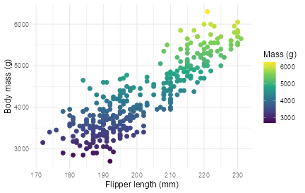

Here hovering each row shows **only** that palette — no cumulative stacking, because every row points at its own pre-rendered image.

## Recap

| Feature | How |
| --- | --- |
| Incremental reveal | `ch_hover({ ... })` (default) |
| Highlight one row | `ch_hover(..., type = "one_row")` |
| Stable axes across steps | `ch_hover(..., fixed_scales = TRUE)` |
| Image placement | `ch_hover(..., layout = "auto" / "row" / "column")` |
| Custom styling | `ch_hover(..., css_class = "...")` + a `<style>` block |
| Clean source | `ch_hover_chunk("label")` on an `eval=FALSE` chunk |
| Smaller HTML | `ch_hover(..., path = "folder/")` |
| Full control / any images | `ch_int()` → `ch_row()` → `ch_out()` |